# exercise-11

Riley N Derby

2024-03-26

exercise 11

load in bird dataset and winnow down to 19 variables

```r
library(tidyverse)
library(car)
library(broom)
```

```r
library(ggplot2)
library(manipulate)
f <- "https://raw.githubusercontent.com/difiore/ada-2024-datasets/main/AVONETdataset1.csv"
b <- read_csv(f, col_names = TRUE)
b <- b %>%
  select("Species1", 'Family1', "Order1","Beak.Length_Culmen", "Beak.Width", "Beak.Depth", "Tarsus.Length", "Wing.Length", "Tail.Length", "Mass", "Habitat", "Migration", "Trophic.Level", "Trophic.Niche", "Min.Latitude", "Max.Latitude", "Centroid.Latitude", "Range.Size", "Primary.Lifestyle")
glimpse(b)
```

```
## Rows: 11,009
## Columns: 19
## $ Species1           <chr> "Accipiter albogularis", "Accipiter badius", "Accip…
## $ Family1            <chr> "Accipitridae", "Accipitridae", "Accipitridae", "Ac…
## $ Order1             <chr> "Accipitriformes", "Accipitriformes", "Accipitrifor…
## $ Beak.Length_Culmen <dbl> 27.7, 20.6, 25.0, 22.5, 21.1, 20.0, 20.5, 19.2, 20.…
## $ Beak.Width         <dbl> 10.6, 8.8, 8.6, 8.9, 8.7, 6.6, 8.3, 7.7, 8.6, 8.6, …
## $ Beak.Depth         <dbl> 14.7, 11.6, 12.7, 11.9, 11.1, 12.0, 10.9, 9.6, 11.0…
## $ Tarsus.Length      <dbl> 62.0, 43.0, 58.1, 61.2, 46.4, 48.7, 52.6, 60.3, 43.…
## $ Wing.Length        <dbl> 235.2, 186.7, 229.6, 202.2, 217.6, 166.0, 163.5, 21…
## $ Tail.Length        <dbl> 169.0, 140.6, 186.3, 140.8, 153.5, 127.0, 135.4, 15…
## $ Mass               <dbl> 248.8, 131.2, 287.5, 142.0, 186.5, 122.0, 157.5, 16…
## $ Habitat            <chr> "Forest", "Shrubland", "Woodland", "Forest", "Fores…
## $ Migration          <dbl> 2, 3, 2, 2, 3, 1, 2, 2, 2, 3, 1, 1, 1, 1, 2, 1, 3, …
## $ Trophic.Level      <chr> "Carnivore", "Carnivore", "Carnivore", "Carnivore",…
## $ Trophic.Niche      <chr> "Vertivore", "Vertivore", "Vertivore", "Vertivore",…
## $ Min.Latitude       <dbl> -11.73, -29.47, -55.72, -6.31, 31.19, 7.87, -10.36,…
## $ Max.Latitude       <dbl> -4.02, 46.39, 23.73, -4.08, 55.86, 9.26, 10.12, 0.0…
## $ Centroid.Latitude  <dbl> -8.15, 8.23, -10.10, -5.45, 45.24, 8.42, 0.71, -23.…
## $ Range.Size         <dbl> 37461.21, 22374973.00, 14309701.27, 35580.71, 29367…
## $ Primary.Lifestyle  <chr> "Insessorial", "Insessorial", "Generalist", "Insess…
```

—Challenge 1—

Step 1 Make boxplots of log(Mass) in relation to Trophic.Level and Migration behavior type. For each plot, drop from the visualization all species records where the categorical variable of interest is missing from the dataset. Also, you will want to convert the variable Migration (which is scored as a number: “1”, “2”, or “3”) from class numeric to either being classified as a factor or as a character (string) variable.

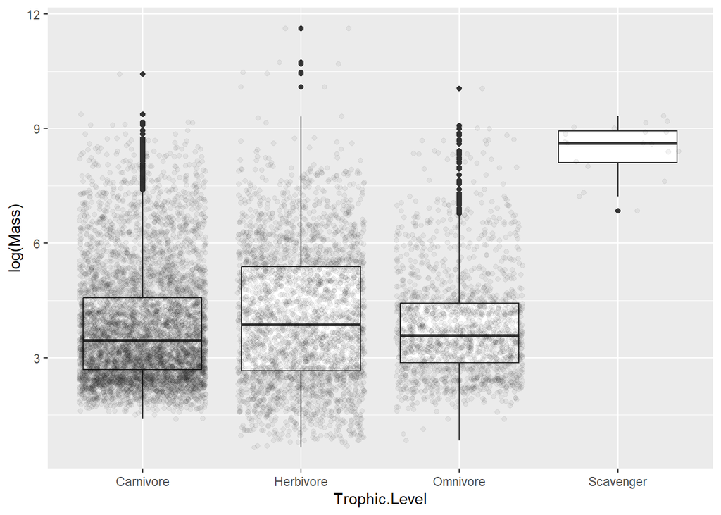

```r
ggplot(data = b %>% drop_na(Trophic.Level),
       aes(x= Trophic.Level, y = log(Mass))) +
  geom_boxplot()+
  geom_jitter(alpha = 0.05)
```

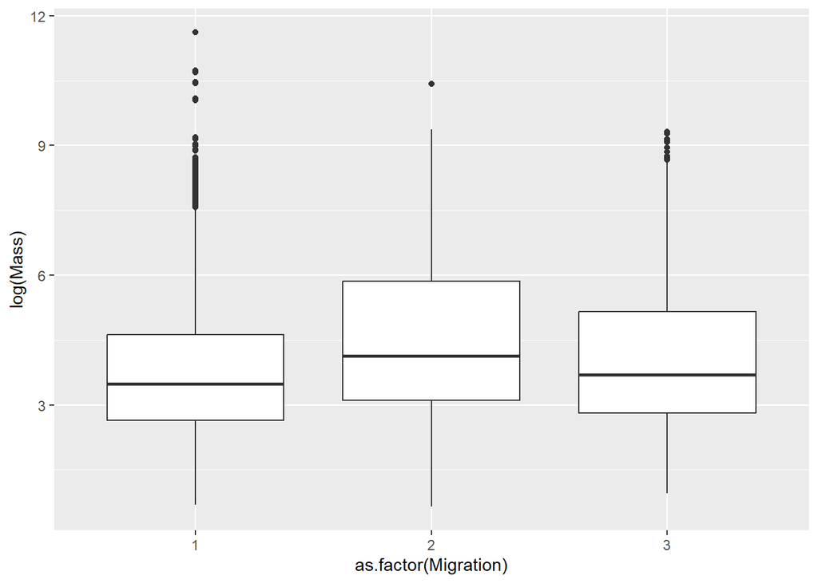

```r
ggplot(data = b %>% drop_na(Migration),
       aes(x= as.factor(Migration), y = log(Mass))) +
  geom_boxplot()
```

Step 2 Run linear models using the lm() function to look at the relationship between log(Mass) and Trophic.Level and between log(Mass) and Migration.

```r
m1 <- lm(data = b, log(Mass)~ Trophic.Level)


b <- b %>% mutate(Migration = as.factor(Migration)) #change migration to categorical from here on out
m2 <- lm(data = b, log(Mass)~ Migration)

summary(m1)
```

```
##
## Call:
## lm(formula = log(Mass) ~ Trophic.Level, data = b)
##
## Residuals:
##     Min      1Q  Median      3Q     Max
## -3.4229 -1.1551 -0.3028  0.8982  7.5526
##
## Coefficients:
##                        Estimate Std. Error t value Pr(>|t|)
## (Intercept)             3.80834    0.01967 193.632  < 2e-16 ***
## Trophic.LevelHerbivore  0.25639    0.03406   7.528 5.54e-14 ***
## Trophic.LevelOmnivore   0.01422    0.04116   0.345     0.73
## Trophic.LevelScavenger  4.63189    0.34447  13.446  < 2e-16 ***
## ---
## Signif. codes:  0 '***' 0.001 '**' 0.01 '*' 0.05 '.' 0.1 ' ' 1
##
## Residual standard error: 1.538 on 11000 degrees of freedom
##   (5 observations deleted due to missingness)
## Multiple R-squared:  0.02094,    Adjusted R-squared:  0.02067
## F-statistic: 78.42 on 3 and 11000 DF,  p-value: < 2.2e-16
```

```r
summary(m2)
```

```
##
## Call:
## lm(formula = log(Mass) ~ Migration, data = b)
##
## Residuals:
##     Min      1Q  Median      3Q     Max
## -3.8924 -1.1769 -0.3088  0.9152  7.8427
##
## Coefficients:
##             Estimate Std. Error t value Pr(>|t|)
## (Intercept)  3.77457    0.01636 230.710  < 2e-16 ***
## Migration2   0.75971    0.04731  16.059  < 2e-16 ***
## Migration3   0.37647    0.05155   7.303 3.02e-13 ***
## ---
## Signif. codes:  0 '***' 0.001 '**' 0.01 '*' 0.05 '.' 0.1 ' ' 1
##
## Residual standard error: 1.535 on 10983 degrees of freedom
##   (23 observations deleted due to missingness)
## Multiple R-squared:  0.02563,    Adjusted R-squared:  0.02546
## F-statistic: 144.5 on 2 and 10983 DF,  p-value: < 2.2e-16
```

Examine the output of the resultant linear models. Is log(Mass) associated with either Trophic.Level or Migration category? That is, in the global test of significance, is the F statistic large enough to reject the null hypothesis of an F value of zero?

– The overall models are both significant

Given the regression coefficients returned for your Migration model, which Migration categor(ies) are different than the reference level? What level is the reference level? Relevel and assess differences among the remaining pair of Migration categories.

–for migration the intercept is category 1

lets relevel the factors

```r
b1<- b %>%
  mutate(Migration = relevel(Migration, ref = "3"))

m3<- lm(log(Mass) ~ Migration, data = b1)
summary(m3)
```

```
##
## Call:
## lm(formula = log(Mass) ~ Migration, data = b1)
##
## Residuals:
##     Min      1Q  Median      3Q     Max
## -3.8924 -1.1769 -0.3088  0.9152  7.8427
##
## Coefficients:
##             Estimate Std. Error t value Pr(>|t|)
## (Intercept)  4.15104    0.04889  84.909  < 2e-16 ***
## Migration1  -0.37647    0.05155  -7.303 3.02e-13 ***
## Migration2   0.38324    0.06603   5.804 6.67e-09 ***
## ---
## Signif. codes:  0 '***' 0.001 '**' 0.01 '*' 0.05 '.' 0.1 ' ' 1
##
## Residual standard error: 1.535 on 10983 degrees of freedom
##   (23 observations deleted due to missingness)
## Multiple R-squared:  0.02563,    Adjusted R-squared:  0.02546
## F-statistic: 144.5 on 2 and 10983 DF,  p-value: < 2.2e-16
```

```r
### look at the difference between summary(m2) and summary and (m3) see that migration 3 has now moved to intercept
```

Step 3 Conduct a post-hoc Tukey Honest Significant Differences test to also evaluate which Migration categories differ “significantly” from one another (see Module 20).

```r
#THSD test
m1 <- lm(log(Mass) ~ Trophic.Level, data = b)
summary(m1)
```

```
##
## Call:
## lm(formula = log(Mass) ~ Trophic.Level, data = b)
##
## Residuals:
##     Min      1Q  Median      3Q     Max
## -3.4229 -1.1551 -0.3028  0.8982  7.5526
##
## Coefficients:
##                        Estimate Std. Error t value Pr(>|t|)
## (Intercept)             3.80834    0.01967 193.632  < 2e-16 ***
## Trophic.LevelHerbivore  0.25639    0.03406   7.528 5.54e-14 ***
## Trophic.LevelOmnivore   0.01422    0.04116   0.345     0.73
## Trophic.LevelScavenger  4.63189    0.34447  13.446  < 2e-16 ***
## ---
## Signif. codes:  0 '***' 0.001 '**' 0.01 '*' 0.05 '.' 0.1 ' ' 1
##
## Residual standard error: 1.538 on 11000 degrees of freedom
##   (5 observations deleted due to missingness)
## Multiple R-squared:  0.02094,    Adjusted R-squared:  0.02067
## F-statistic: 78.42 on 3 and 11000 DF,  p-value: < 2.2e-16
```

```r
m1aov <- aov(log(Mass) ~ Trophic.Level, data = b)
summary(m1aov)
```

```
##                  Df Sum Sq Mean Sq F value Pr(>F)
## Trophic.Level     3    557  185.50   78.42 <2e-16 ***
## Residuals     11000  26020    2.37
## ---
## Signif. codes:  0 '***' 0.001 '**' 0.01 '*' 0.05 '.' 0.1 ' ' 1
## 5 observations deleted due to missingness
```

```r
pairwise.t.test(log(b$Mass), b$Trophic.Level, p.adj = "bonferroni")
```

```
##
##  Pairwise comparisons using t tests with pooled SD
##
## data:  log(b$Mass) and b$Trophic.Level
##
##           Carnivore Herbivore Omnivore
## Herbivore 3.3e-13   -         -
## Omnivore  1         6.7e-07   -
## Scavenger < 2e-16   < 2e-16   < 2e-16
##
## P value adjustment method: bonferroni
```

```r
posthoc <- TukeyHSD(m1aov, which = 'Trophic.Level', conf.level = 0.95)
posthoc
```

```
##   Tukey multiple comparisons of means
##     95% family-wise confidence level
##
## Fit: aov(formula = log(Mass) ~ Trophic.Level, data = b)
##
## $Trophic.Level
##                            diff         lwr        upr     p adj
## Herbivore-Carnivore  0.25638774  0.16888205  0.3438934 0.0000000
## Omnivore-Carnivore   0.01422185 -0.09154436  0.1199881 0.9858317
## Scavenger-Carnivore  4.63188503  3.74679736  5.5169727 0.0000000
## Omnivore-Herbivore  -0.24216589 -0.35936711 -0.1249647 0.0000007
## Scavenger-Herbivore  4.37549729  3.48897045  5.2620241 0.0000000
## Scavenger-Omnivore   4.61766318  3.72914808  5.5061783 0.0000000
```

Step 4 Use a permutation approach to inference to generate a null distribution of F statistic values for the model of log(Mass) in relation to Trophic.Level and calculate a p value for your original F statistic. You can do this either by programming your own permutation test (e.g., by shuffling values for the predictor or response variable among observations and calculating an F statistic for each replicate) or by using the {infer} workflow and setting calculate(stat=“F”)

```r
original.F <- aov(log(Mass) ~ Trophic.Level, data = b) %>%
  tidy() %>%
  filter(term == "Trophic.Level")

original.F #results for F stat and p value for omnibus F test
```

```
## # A tibble: 1 × 6
##   term             df sumsq meansq statistic  p.value
##   <chr>         <dbl> <dbl>  <dbl>     <dbl>    <dbl>
## 1 Trophic.Level     3  557.   186.      78.4 3.43e-50
```

```r
library(infer)
b <-
  b %>%
  mutate(logMass = log(Mass))

permuted.F <- b %>%
  specify(logMass ~ Trophic.Level) %>%
  hypothesize(null = "independence") %>%
  generate(reps = 1000, type = "permute") %>%
  calculate(stat = "F")
str(permuted.F)
```

```
## infer [1,000 × 2] (S3: infer/tbl_df/tbl/data.frame)
##  $ replicate: int [1:1000] 1 2 3 4 5 6 7 8 9 10 ...
##  $ stat     : num [1:1000] 1.409 0.666 0.6 1.03 1.939 ...
##  - attr(*, "response")= symbol logMass
##  - attr(*, "explanatory")= symbol Trophic.Level
##  - attr(*, "response_type")= chr "numeric"
##  - attr(*, "explanatory_type")= Named chr "factor"
##   ..- attr(*, "names")= chr "explanatory_variable(x)"
##  - attr(*, "distr_param")= int 3
##  - attr(*, "distr_param2")= int 11000
##  - attr(*, "null")= chr "independence"
##  - attr(*, "theory_type")= chr "ANOVA"
##  - attr(*, "generated")= logi TRUE
##  - attr(*, "type")= chr "permute"
##  - attr(*, "hypothesized")= logi TRUE
##  - attr(*, "formula")=Class 'formula'  language logMass ~ Trophic.Level
##   .. ..- attr(*, ".Environment")=<environment: 0x000001ef22d7a738>
##  - attr(*, "fitted")= logi FALSE
##  - attr(*, "type_desc_response")= chr "num"
##  - attr(*, "type_desc_explanatory")= chr "mult"
##  - attr(*, "stat")= chr "F"
```

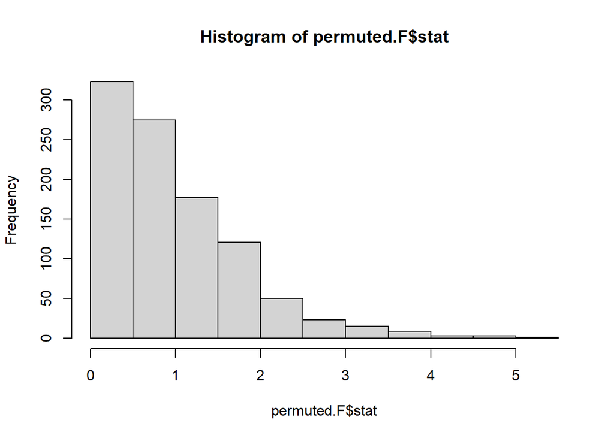

```r
hist(permuted.F$stat)
```

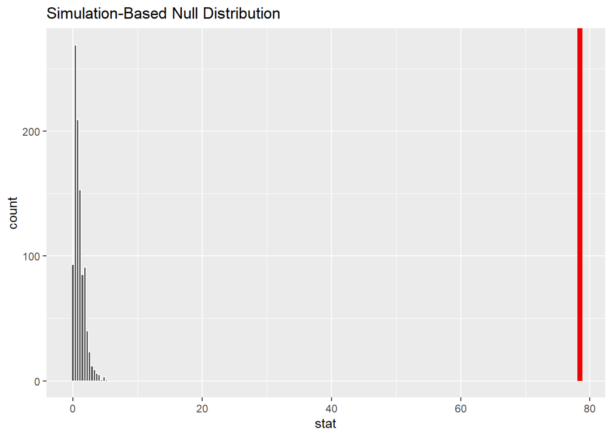

```r
visualize(permuted.F) +
  shade_p_value(obs_stat = original.F$statistic, direction = "greater")
```

—Challenge 2—

Step 1 Create the following two new variables and add them to AVONET dataset: Relative beak length, which you should calculate as the residual of log(Beak.Length_Culmen) on log(Mass). Relative tarsus length, which you should calculate as the residual of log(Tarsus.Length) on log(Mass).

```r
b$relBL <- resid(lm(formula = log(Beak.Length_Culmen)~ log(Mass), data = b))

b$relTL <- resid(lm(formula = log(Tarsus.Length)~ log(Mass), data = b))
```

Step 2 Make a boxplot or violin plot of your new relative tarsus length variable in relation to Primary.Lifestyle and of your new relative beak length variable in relation to Trophic.Niche

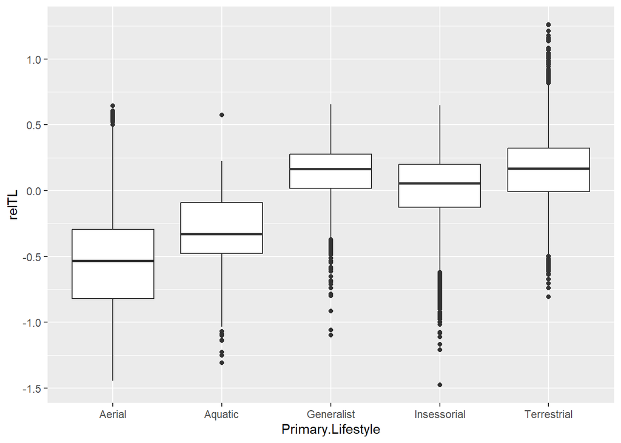

```r
ggplot(data = b %>%
          filter(!is.na(Primary.Lifestyle)),
       aes(x= Primary.Lifestyle, y = relTL)) +
  geom_boxplot()
```

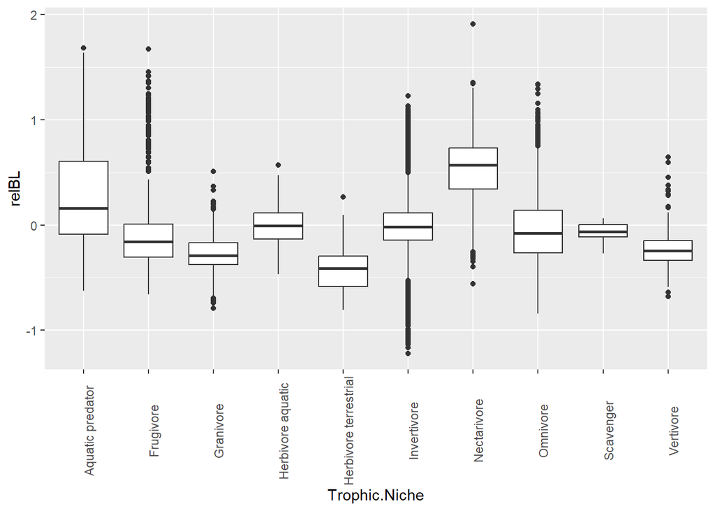

```r
ggplot(data = b %>%
          filter(!is.na(Trophic.Niche)),
       aes(x= Trophic.Niche, y = relBL)) +
  geom_boxplot()+
  theme(axis.text.x = element_text(angle = 90))
```

Step 3 Run an ANOVA analyses to look at the association between geographic range size and the variable Migration. You should first drop those observations for which Migration is not scored and also look at the distribution of the variable Range.Size to decide whether and how it might need to be transformed. Based on the global model, is range size associated with form of migration? How much of the variance in your measure of range size is associated with Migration behavior style?

Given the regression coefficients returned in output of the model, which Migration categor(ies) are different than the reference level? What level is the reference level? Relevel and assess differences among the remaining pair of Migration categories. Also conduct a post-hoc Tukey Honest Significant Differences test to also evaluate which Migration categories differ “significantly” from one another (see Module 20).

```r
m3 <- lm(Range.Size ~ as.factor(Migration), data = b)
summary(m3)
```

```
##
## Call:
## lm(formula = Range.Size ~ as.factor(Migration), data = b)
##
## Residuals:
##       Min        1Q    Median        3Q       Max
##  -7435666  -1480415  -1308364    -97217 129649325
##
## Coefficients:
##                       Estimate Std. Error t value Pr(>|t|)
## (Intercept)            1487601      78049   19.06   <2e-16 ***
## as.factor(Migration)2  5167507     225862   22.88   <2e-16 ***
## as.factor(Migration)3  5948066     246158   24.16   <2e-16 ***
## ---
## Signif. codes:  0 '***' 0.001 '**' 0.01 '*' 0.05 '.' 0.1 ' ' 1
##
## Residual standard error: 7308000 on 10934 degrees of freedom
##   (72 observations deleted due to missingness)
## Multiple R-squared:  0.08365,    Adjusted R-squared:  0.08349
## F-statistic: 499.1 on 2 and 10934 DF,  p-value: < 2.2e-16
```

```r
m3 <- aov(Range.Size ~ as.factor(Migration), data = b)
summary(m3)
```

```
##                         Df    Sum Sq   Mean Sq F value Pr(>F)
## as.factor(Migration)     2 5.331e+16 2.666e+16   499.1 <2e-16 ***
## Residuals            10934 5.840e+17 5.341e+13
## ---
## Signif. codes:  0 '***' 0.001 '**' 0.01 '*' 0.05 '.' 0.1 ' ' 1
## 72 observations deleted due to missingness
```

```r
#significant relationship between range size and migration category

TukeyHSD(m3)
```

```
##   Tukey multiple comparisons of means
##     95% family-wise confidence level
##
## Fit: aov(formula = Range.Size ~ as.factor(Migration), data = b)
##
## $`as.factor(Migration)`
##          diff       lwr     upr     p adj
## 2-1 5167506.6 4638082.5 5696931 0.0000000
## 3-1 5948065.8 5371066.7 6525065 0.0000000
## 3-2  780559.2   41453.6 1519665 0.0355345
```

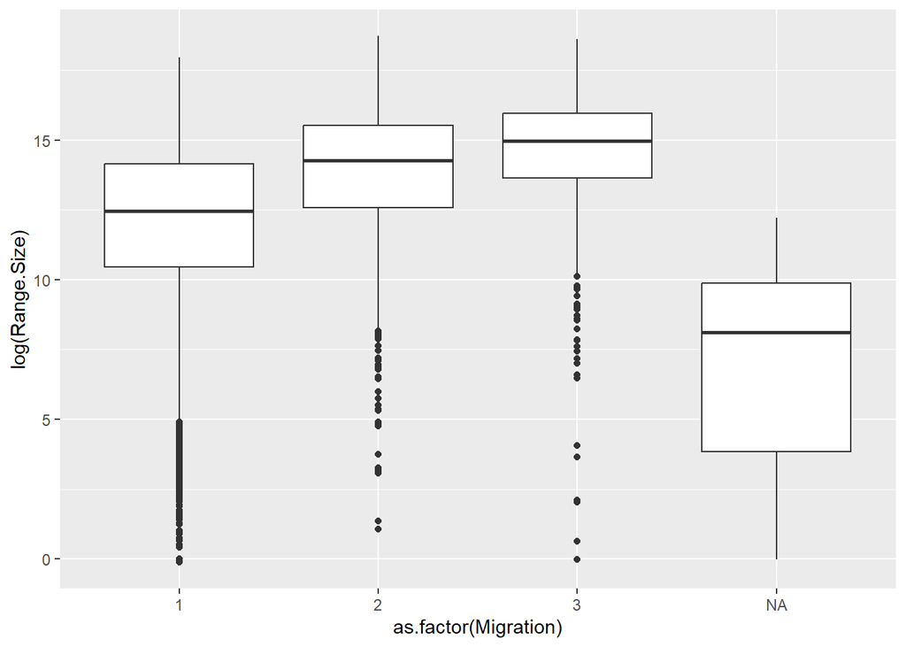

```r
ggplot(b, aes(x= as.factor(Migration), y = log(Range.Size)))+
         geom_boxplot()
```

–Migration category 1 is the reference level and it looks like there is a signifcant relationship between range size and migration category. The 3 categories are all different from one another as well.

Step 4 Winnow your original data to just consider birds from the Infraorder “Passeriformes” (song birds).

Run separate one-factor ANOVA analyses to look at the association between [1] relative beak length and Primary.Lifestyle and between [2] relative beak length and Trophic.Level. In doing so…

Make boxplots of response variable by each predictor and by the combination of predictors.

Run linear models for each predictor separately and interpret the model output.

```r
b1 <- b %>%
  filter(Order1 == "Passeriformes")

b1
```

```
## # A tibble: 6,614 × 22
##    Species1              Family1 Order1 Beak.Length_Culmen Beak.Width Beak.Depth
##    <chr>                 <chr>   <chr>               <dbl>      <dbl>      <dbl>
##  1 Acanthisitta chloris  Acanth… Passe…               12.1        2.4        2.2
##  2 Xenicus gilviventris  Acanth… Passe…               13.8        3.9        3.3
##  3 Acanthiza apicalis    Acanth… Passe…               11          2.2        2.6
##  4 Acanthiza chrysorrhoa Acanth… Passe…               11.7        2.1        2.5
##  5 Acanthiza cinerea     Acanth… Passe…               10.6        2.6        2.8
##  6 Acanthiza ewingii     Acanth… Passe…               10.7        1.9        2.5
##  7 Acanthiza inornata    Acanth… Passe…               11.3        2.3        2.7
##  8 Acanthiza iredalei    Acanth… Passe…                9.2        2          2.3
##  9 Acanthiza katherina   Acanth… Passe…               11.5        2.4        2.6
## 10 Acanthiza lineata     Acanth… Passe…                9.9        2.1        2.8
## # ℹ 6,604 more rows
## # ℹ 16 more variables: Tarsus.Length <dbl>, Wing.Length <dbl>,
## #   Tail.Length <dbl>, Mass <dbl>, Habitat <chr>, Migration <fct>,
## #   Trophic.Level <chr>, Trophic.Niche <chr>, Min.Latitude <dbl>,
## #   Max.Latitude <dbl>, Centroid.Latitude <dbl>, Range.Size <dbl>,
## #   Primary.Lifestyle <chr>, logMass <dbl>, relBL <dbl>, relTL <dbl>
```

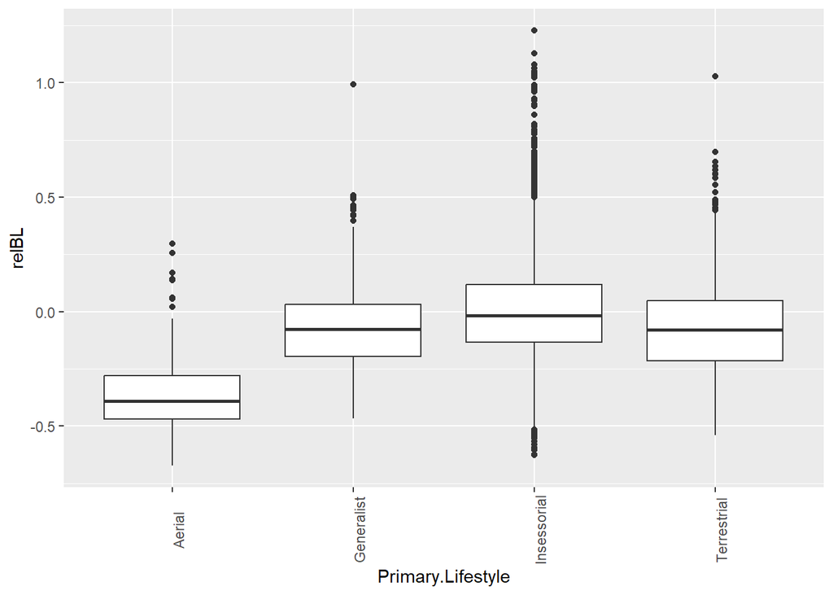

```r
ggplot(data = b1 %>%
          filter(!is.na(Primary.Lifestyle)),
       aes(x= Primary.Lifestyle, y = relBL)) +
  geom_boxplot()+
  theme(axis.text.x = element_text(angle = 90))
```

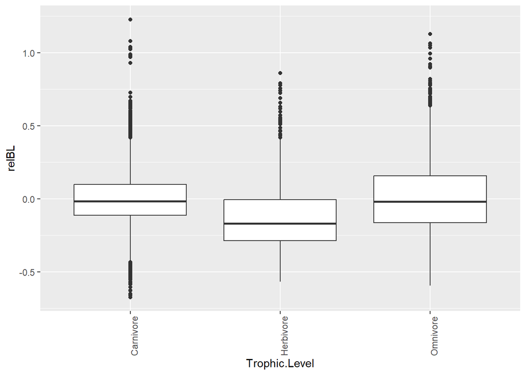

```r
ggplot(data = b1 %>%
          filter(!is.na(Trophic.Level)),
       aes(x= Trophic.Level, y = relBL)) +
  geom_boxplot()+
  theme(axis.text.x = element_text(angle = 90))
```

```r
#models
m4 <- lm(relBL ~ Primary.Lifestyle, data = b1)
summary(m4)
```

```
##
## Call:
## lm(formula = relBL ~ Primary.Lifestyle, data = b1)
##
## Residuals:
##     Min      1Q  Median      3Q     Max
## -0.6314 -0.1380 -0.0172  0.1118  1.2241
##
## Coefficients:
##                              Estimate Std. Error t value Pr(>|t|)
## (Intercept)                  -0.34950    0.02158  -16.19   <2e-16 ***
## Primary.LifestyleGeneralist   0.27926    0.02306   12.11   <2e-16 ***
## Primary.LifestyleInsessorial  0.35342    0.02181   16.20   <2e-16 ***
## Primary.LifestyleTerrestrial  0.27924    0.02249   12.42   <2e-16 ***
## ---
## Signif. codes:  0 '***' 0.001 '**' 0.01 '*' 0.05 '.' 0.1 ' ' 1
##
## Residual standard error: 0.2158 on 6610 degrees of freedom
## Multiple R-squared:  0.05581,    Adjusted R-squared:  0.05538
## F-statistic: 130.2 on 3 and 6610 DF,  p-value: < 2.2e-16
```

```r
maov4 <- lm(relBL ~ Primary.Lifestyle, data = b1)
summary(maov4)
```

```
##
## Call:
## lm(formula = relBL ~ Primary.Lifestyle, data = b1)
##
## Residuals:
##     Min      1Q  Median      3Q     Max
## -0.6314 -0.1380 -0.0172  0.1118  1.2241
##
## Coefficients:
##                              Estimate Std. Error t value Pr(>|t|)
## (Intercept)                  -0.34950    0.02158  -16.19   <2e-16 ***
## Primary.LifestyleGeneralist   0.27926    0.02306   12.11   <2e-16 ***
## Primary.LifestyleInsessorial  0.35342    0.02181   16.20   <2e-16 ***
## Primary.LifestyleTerrestrial  0.27924    0.02249   12.42   <2e-16 ***
## ---
## Signif. codes:  0 '***' 0.001 '**' 0.01 '*' 0.05 '.' 0.1 ' ' 1
##
## Residual standard error: 0.2158 on 6610 degrees of freedom
## Multiple R-squared:  0.05581,    Adjusted R-squared:  0.05538
## F-statistic: 130.2 on 3 and 6610 DF,  p-value: < 2.2e-16
```

```r
m5 <- lm(relBL ~ Trophic.Level, data = b1)
summary(m5)
```

```
##
## Call:
## lm(formula = relBL ~ Trophic.Level, data = b1)
##
## Residuals:
##      Min       1Q   Median       3Q      Max
## -0.67045 -0.13692 -0.02063  0.11129  1.23116
##
## Coefficients:
##                         Estimate Std. Error t value Pr(>|t|)
## (Intercept)            -0.003170   0.003501  -0.906  0.36518
## Trophic.LevelHerbivore -0.118713   0.006956 -17.066  < 2e-16 ***
## Trophic.LevelOmnivore   0.017902   0.006606   2.710  0.00675 **
## ---
## Signif. codes:  0 '***' 0.001 '**' 0.01 '*' 0.05 '.' 0.1 ' ' 1
##
## Residual standard error: 0.2165 on 6611 degrees of freedom
## Multiple R-squared:  0.05001,    Adjusted R-squared:  0.04972
## F-statistic:   174 on 2 and 6611 DF,  p-value: < 2.2e-16
```

```r
maov5 <- aov(relBL ~ Trophic.Level, data = b1)
summary(maov5)
```

```
##                 Df Sum Sq Mean Sq F value Pr(>F)
## Trophic.Level    2  16.31   8.154     174 <2e-16 ***
## Residuals     6611 309.81   0.047
## ---
## Signif. codes:  0 '***' 0.001 '**' 0.01 '*' 0.05 '.' 0.1 ' ' 1
```

Step 5 Run a two-factor model to look at the association between relative beak length and both Primary.Lifestyle and Trophic.Level among the passeriforms. Based on the model output, what would you conclude about how relative beak length is related to these two variables?

```r
m6 <- lm(relBL ~ Trophic.Level + Primary.Lifestyle, data = b1)
summary(m6)
```

```
##
## Call:
## lm(formula = relBL ~ Trophic.Level + Primary.Lifestyle, data = b1)
##
## Residuals:
##      Min       1Q   Median       3Q      Max
## -0.65365 -0.13329 -0.02284  0.10274  1.20180
##
## Coefficients:
##                               Estimate Std. Error t value Pr(>|t|)
## (Intercept)                  -0.349502   0.020958 -16.677   <2e-16 ***
## Trophic.LevelHerbivore       -0.126397   0.006761 -18.695   <2e-16 ***
## Trophic.LevelOmnivore         0.012140   0.006450   1.882   0.0599 .
## Primary.LifestyleGeneralist   0.301517   0.022582  13.352   <2e-16 ***
## Primary.LifestyleInsessorial  0.375698   0.021295  17.642   <2e-16 ***
## Primary.LifestyleTerrestrial  0.302119   0.021942  13.769   <2e-16 ***
## ---
## Signif. codes:  0 '***' 0.001 '**' 0.01 '*' 0.05 '.' 0.1 ' ' 1
##
## Residual standard error: 0.2096 on 6608 degrees of freedom
## Multiple R-squared:   0.11,  Adjusted R-squared:  0.1093
## F-statistic: 163.4 on 5 and 6608 DF,  p-value: < 2.2e-16
```

```r
maov6 <- aov(relBL ~ Trophic.Level + Primary.Lifestyle, data = b1)
summary(maov6)
```

```
##                     Df Sum Sq Mean Sq F value Pr(>F)
## Trophic.Level        2  16.31   8.154   185.7 <2e-16 ***
## Primary.Lifestyle    3  19.57   6.523   148.5 <2e-16 ***
## Residuals         6608 290.24   0.044
## ---
## Signif. codes:  0 '***' 0.001 '**' 0.01 '*' 0.05 '.' 0.1 ' ' 1
```

```r
#beak length is impacted by trophic level and lifestyle with non-significant effect for ominvores, but a trend
```

Step 6 Finally, run an additional two-way model with the same dataset and predictors, but adding the possibility of an interaction term. To do this, you should modify your model formula using the colon operator (:) to specify the interaction, e.g., relative beak length ~ Primary.Lifestyle + Trophic.Level + Primary.Lifestyle:Trophic.Level. Based on the model output, what would you now conclude about how relative beak length is related to these two variables?

```r
m7 <- lm(relBL~ Trophic.Level + Primary.Lifestyle + Trophic.Level:Primary.Lifestyle, data = b1)
summary(m7)
```

```
##
## Call:
## lm(formula = relBL ~ Trophic.Level + Primary.Lifestyle + Trophic.Level:Primary.Lifestyle,
##     data = b1)
##
## Residuals:
##      Min       1Q   Median       3Q      Max
## -0.64623 -0.12836 -0.02078  0.10070  1.21924
##
## Coefficients: (2 not defined because of singularities)
##                                                     Estimate Std. Error t value
## (Intercept)                                         -0.34950    0.02066 -16.918
## Trophic.LevelHerbivore                              -0.27502    0.01562 -17.608
## Trophic.LevelOmnivore                               -0.11080    0.01550  -7.150
## Primary.LifestyleGeneralist                          0.33010    0.02367  13.948
## Primary.LifestyleInsessorial                         0.35826    0.02104  17.031
## Primary.LifestyleTerrestrial                         0.35714    0.02210  16.162
## Trophic.LevelHerbivore:Primary.LifestyleGeneralist   0.05033    0.02584   1.948
## Trophic.LevelOmnivore:Primary.LifestyleGeneralist    0.09898    0.02351   4.210
## Trophic.LevelHerbivore:Primary.LifestyleInsessorial  0.20115    0.01750  11.494
## Trophic.LevelOmnivore:Primary.LifestyleInsessorial   0.15527    0.01726   8.996
## Trophic.LevelHerbivore:Primary.LifestyleTerrestrial       NA         NA      NA
## Trophic.LevelOmnivore:Primary.LifestyleTerrestrial        NA         NA      NA
##                                                     Pr(>|t|)
## (Intercept)                                          < 2e-16 ***
## Trophic.LevelHerbivore                               < 2e-16 ***
## Trophic.LevelOmnivore                               9.61e-13 ***
## Primary.LifestyleGeneralist                          < 2e-16 ***
## Primary.LifestyleInsessorial                         < 2e-16 ***
## Primary.LifestyleTerrestrial                         < 2e-16 ***
## Trophic.LevelHerbivore:Primary.LifestyleGeneralist    0.0515 .
## Trophic.LevelOmnivore:Primary.LifestyleGeneralist   2.59e-05 ***
## Trophic.LevelHerbivore:Primary.LifestyleInsessorial  < 2e-16 ***
## Trophic.LevelOmnivore:Primary.LifestyleInsessorial   < 2e-16 ***
## Trophic.LevelHerbivore:Primary.LifestyleTerrestrial       NA
## Trophic.LevelOmnivore:Primary.LifestyleTerrestrial        NA
## ---
## Signif. codes:  0 '***' 0.001 '**' 0.01 '*' 0.05 '.' 0.1 ' ' 1
##
## Residual standard error: 0.2066 on 6604 degrees of freedom
## Multiple R-squared:  0.1358, Adjusted R-squared:  0.1346
## F-statistic: 115.3 on 9 and 6604 DF,  p-value: < 2.2e-16
```

```r
maov7 <- aov(relBL~ Trophic.Level + Primary.Lifestyle + Trophic.Level:Primary.Lifestyle, data = b1)
summary(maov7)
```

```
##                                   Df Sum Sq Mean Sq F value Pr(>F)
## Trophic.Level                      2  16.31   8.154  191.08 <2e-16 ***
## Primary.Lifestyle                  3  19.57   6.523  152.84 <2e-16 ***
## Trophic.Level:Primary.Lifestyle    4   8.41   2.102   49.26 <2e-16 ***
## Residuals                       6604 281.83   0.043
## ---
## Signif. codes:  0 '***' 0.001 '**' 0.01 '*' 0.05 '.' 0.1 ' ' 1
```

```r
#beak length, trophic level, and lifestyle influence one another
```

Step 7 Use the interaction.plot() function to visualize the interaction between Primary.Lifestyle and Trophic.Level (see Module 20).

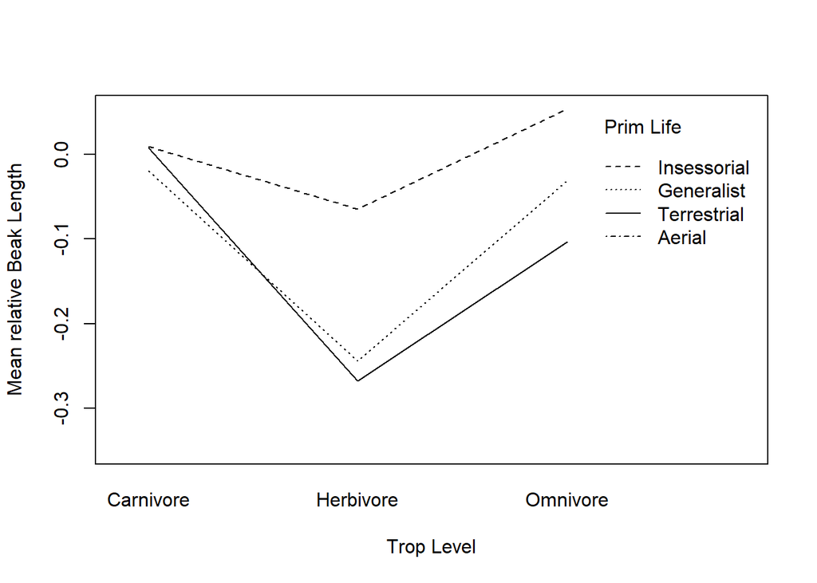

```r
interaction.plot(x.factor = b1$Trophic.Level,
                 xlab = "Trop Level",
                 trace.factor = b1$Primary.Lifestyle,
                 trace.label = 'Prim Life',
                 response = b1$relBL,
                 ylab = 'Mean relative Beak Length')
```

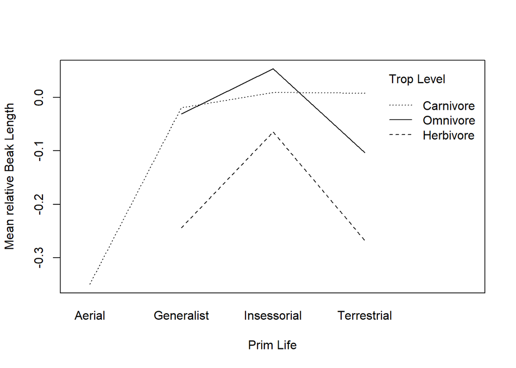

```r
##flip troph level and prim lifestyle to visualize the other way
interaction.plot(x.factor = b1$Primary.Lifestyle,
                 xlab = "Prim Life",
                 trace.factor = b1$Trophic.Level,
                 trace.label = 'Trop Level',
                 response = b1$relBL,
                 ylab = 'Mean relative Beak Length')
```